# newton_raphson_simulation

Yunfan Li

2019/4/4

## 实验报告

### 实验名称： 牛顿法

#### 16302010002 李云帆

#### 实验内容解读：

牛顿法就是把非线性函数f(x)=0,在x0处展开成泰勒级数，取其线性部分，作为非线性方程的近似方程 再把f(x)在x1 处展开为泰勒级数，取其线性部分为f(x)=0的近似方程，若f’(x)!=0，则得x2=x1-f(x1)/f’(x1)如此继续下去，得到牛顿法的迭代公式 x_{n+1}=xn-f(xn)/f’(xn). 通过迭代，这个式子必然在f(x)=0的时候收敛，此时得到函数零点的近似解

```r
# 牛顿法的cost function
nll <- function(X, y, beta) {
  ##return negative log-likelihood
  beta = as.vector(beta)
  z <-  X %*% beta
  LL <- t(y) %*% z - sum(log(1 + exp(z)))
  return (-LL)
}
# 矩阵的二阶导
hessian <- function(X, beta) {
  # returns the Hessian of the log-likelihood
  p<-logitWithBeta(X,beta)
  w <- diag(c(p * (1-p)))
  J <- t(X) %*% w %*% X
  return (J)
}
# 矩阵的一阶导
gradient <- function(X, y, beta) {
  # returns the gradient of the log-likelihood
  p<-logitWithBeta(X,beta)
  score <- t(X) %*% (y - p)
  return (score)
}

# 牛顿法就是把非线性函数f(x)=0,在x0处展开成泰勒级数，取其线性部分，作为非线性方程的近似方程
# 再把f(x)在x1 处展开为泰勒级数，取其线性部分为f(x)=0的近似方程，若f'(x)!=0，则得x2=x1-f(x1)/f'(x1)如此继续下去，得到牛顿法的迭代公式
# x_{n+1}=xn-f(xn)/f'(xn). 通过迭代，这个式子必然在f(x)=0的时候收敛，此时得到函数零点的近似解
glm_Newton <- function(y, X, max.iter = 200, eps = 1e-10) {
  # using newton method
  n.beta <- ncol(X)
  B <-  matrix(NA,ncol = max.iter,nrow = n.beta)
  NLL <- rep(0,max.iter) ###negative LL
  B[,1] <- rep(0,ncol(X)) ##starting value
  NLL[1] <- nll(X,y,B[,1])
  for (i in 2:max.iter) {
    B[,i] <- B[,i-1]+solve(hessian(X,B[,i-1])) %*% gradient(X,y,B[,i-1])
    NLL[i] <- nll(X,y,B[,i-1])
    if (all(abs(B[,i]-B[,i-1]) < eps)) break;
  }
  B <- B[ , !apply(is.na(B), 2, all)] ##remove NA columns if there is any
  NLL <- NLL[NLL>0]
  return (list(B,NLL))
}

glm_GradientDescent <- function(y, X, max.iter = 200, eps = 1e-10) {
  # using gradient descent
  n.beta <- ncol(X)
  B <-  matrix(NA,ncol = max.iter,nrow = n.beta)
  NLL <- rep(0,max.iter) ###negative LL
  B[,1] <- rep(0,ncol(X)) ##starting value
  NLL[1] <- nll(X,y,B[,1])
  alpha <- 4/(svd(cbind(1, X))$d[1]^2)

  for (i in 2:max.iter) {
    B[,i] <- B[,i-1]+alpha*gradient(X,y,B[,i-1])
    NLL[i] <- nll(X,y,B[,i-1])
    if (all(abs(B[,i]-B[,i-1]) < eps)) break;
  }
  B <- B[ , !apply(is.na(B), 2, all)] ##remove NA columns if there is any
  NLL <- NLL[NLL>0]
  return (list(B,NLL))

}

glm_StochasticGradientDescent <- function(y, X, max.iter = 200, eps = 1e-10) {
  # using gradient descent
  n.beta <- ncol(X)
  B <-  matrix(NA,ncol = max.iter,nrow = n.beta)
  NLL <- rep(0,max.iter) ###negative LL
  B[,1] <- rep(0,ncol(X)) ##starting value
  NLL[1] <- nll(X,y,B[,1])
  alpha <- 4/(svd(cbind(1, X))$d[1]^2)

  for (i in 2:max.iter) {
    B[,i] <- B[,i-1]+alpha*gradient(X,y,B[,i-1])
    NLL[i] <- nll(X,y,B[,i-1])
    if (all(abs(B[,i]-B[,i-1]) < eps)) break;
  }
  B <- B[ , !apply(is.na(B), 2, all)] ##remove NA columns if there is any
  NLL <- NLL[NLL>0]
  return (list(B,NLL))

}
```

```r
library(ggplot2)
library(rlist)
set.seed(5)
beta=matrix(c(0.5,1.2,-1),nrow=1,ncol=3)

logitWithBeta = function(X,beta){
  beta = as.vector(beta)
  return(1 / (1+ exp(-X%*%beta)))
}

generateX<-function(N){
  X1=matrix(c(rnorm(N,0,1)),nrow=1,ncol=N,byrow=TRUE)
  X2=matrix(c(rnorm(N,0,1)),nrow=1,ncol=N,byrow=TRUE)
  X0=matrix(c(rnorm(N,1,0)),nrow=1,ncol=N,byrow=TRUE)
  return(matrix(c(X0,X1,X2),nrow=N,ncol=3))
}

simulation<-function(N=200){
  X=generateX(N)
  # dim(X) # 200,3

  # dim(beta) #1,3
  p =logitWithBeta(X,beta)
  Y= rbinom(N,1,p)
  # logisticLM=glm(Y~X,family=binomial(link='logit'))
  # summary(logisticLM)
  nr<-as.matrix(glm_Newton(Y,X,100,1e-10))
  beta_hat<-nr[[1]] # only save the final result
  return(beta_hat[,ncol(beta_hat)])
}

init_betahats<-function(R){return(data.frame(beta1=rep(0,R),beta2=rep(0,R),beta3=rep(0,R)))}
R=200
beta_hats200=init_betahats(R)
beta_hats500=init_betahats(R)
beta_hats800=init_betahats(R)
beta_hats1000=init_betahats(R)

putElementIntoBetahats<-function(beta_hats,betahat,index,R=200){
  if(is.null(beta_hats$beta1)){beta_hats$beta1<-rep(0,R);beta_hats$beta2<-rep(0,R);beta_hats$beta3<-rep(0,R)}
  beta_hats$beta1[index]<-betahat[1]
  beta_hats$beta2[index]=betahat[2]
  beta_hats$beta3[index]=betahat[3]
  return(beta_hats)
}
```

```r
for (time in 1:R) {
a<-simulation(200);beta_hats200<-putElementIntoBetahats(beta_hats200,a,time,R)
b<-simulation(500);beta_hats500<-putElementIntoBetahats(beta_hats500,b,time,R)
c<-simulation(800);beta_hats800<-putElementIntoBetahats(beta_hats800,c,time,R)
d<-simulation(1000);beta_hats1000<-putElementIntoBetahats(beta_hats1000,d,time,R)
}

calc_mean<-function(){
 bh200=c(mean(beta_hats200$beta1),mean(beta_hats200$beta2),mean(beta_hats200$beta3))
 bh500=c(mean(beta_hats500$beta1),mean(beta_hats500$beta2),mean(beta_hats500$beta3))
 bh800=c(mean(beta_hats800$beta1),mean(beta_hats800$beta2),mean(beta_hats800$beta3))
 bh1000=c(mean(beta_hats1000$beta1),mean(beta_hats1000$beta2),mean(beta_hats1000$beta3))
 meanBH=data.frame(bh200,bh500,bh800,bh1000)
 return(meanBH)
}
meanBH<-calc_mean()
meanBH
```

| bh200 | bh500 | bh800 | bh1000 |
| --- | --- | --- | --- |
| 0.5019063 | 0.5027315 | 0.4951577 | 0.5189276 |
| 1.2408470 | 1.2049041 | 1.2118040 | 1.2139937 |
| -1.0156289 | -0.9979704 | -1.0096244 | -0.9979620 |

```r
calc_mean<-function(){
 bh200=c(mean(beta_hats200$beta1)-beta[1],mean(beta_hats200$beta2)-beta[2],mean(beta_hats200$beta3)-beta[3])
 bh500=c(mean(beta_hats500$beta1)-beta[1],mean(beta_hats500$beta2)-beta[2],mean(beta_hats500$beta3)-beta[3])
 bh800=c(mean(beta_hats800$beta1)-beta[1],mean(beta_hats800$beta2)-beta[2],mean(beta_hats800$beta3)-beta[3])
 bh1000=c(mean(beta_hats1000$beta1)-beta[1],mean(beta_hats1000$beta2)-beta[2],mean(beta_hats1000$beta3)-beta[3])
 meanBHDev=data.frame(bh200,bh500,bh800,bh1000)
 return(meanBHDev)
}
meanBHDev<-calc_mean()
meanBHDev
```

| bh200 | bh500 | bh800 | bh1000 |
| --- | --- | --- | --- |
| 0.00190633 | 0.002731484 | -0.004842251 | 0.018927583 |
| 0.04084703 | 0.004904088 | 0.011803998 | 0.013993688 |
| -0.01562888 | 0.002029583 | -0.009624430 | 0.002038038 |

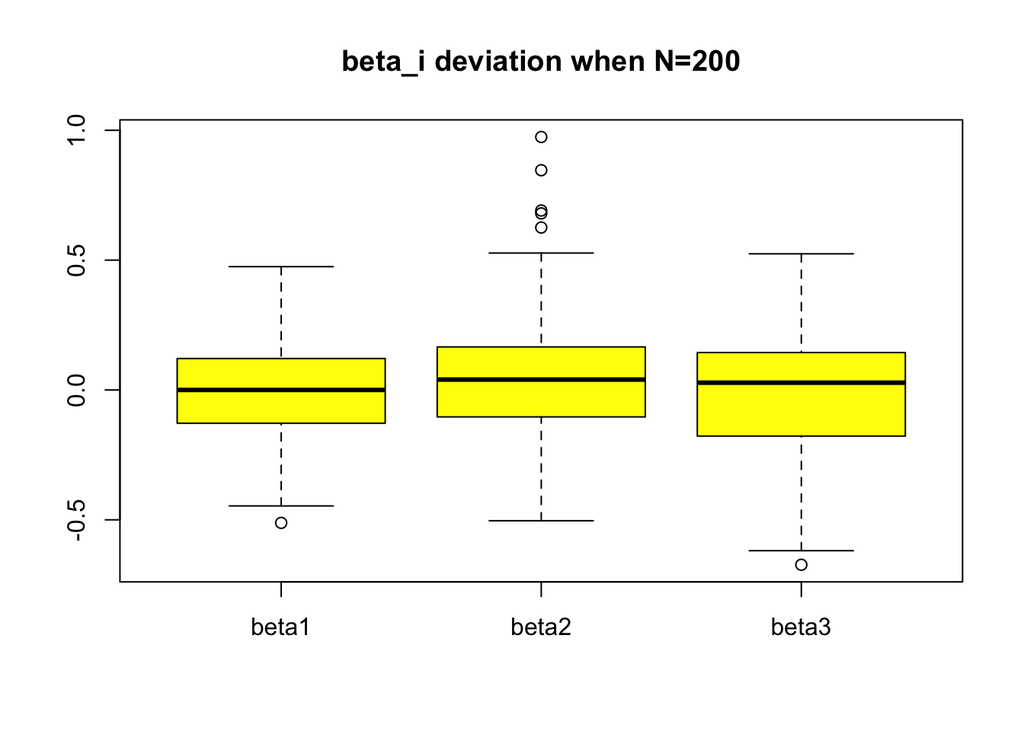

```r
tmp=data.frame(beta1=beta_hats200$beta1-beta[1],beta2=beta_hats200$beta2-beta[2],beta3=beta_hats200$beta3-beta[3])
boxplot(tmp,col = 'yellow',main='beta_i deviation when N=200')
```

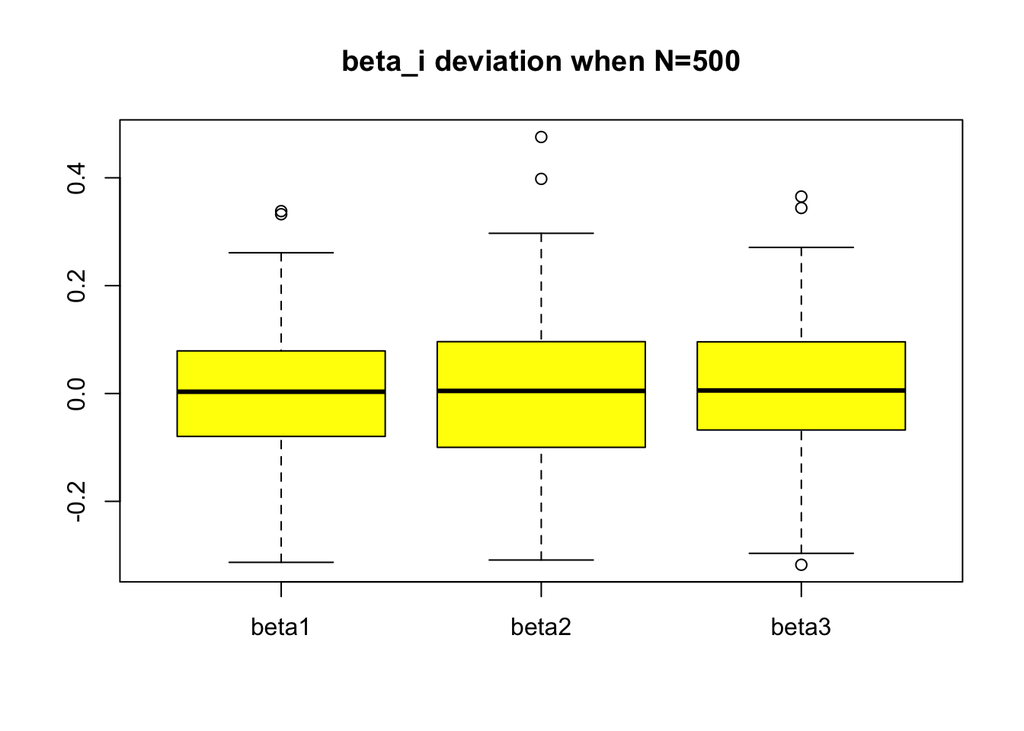

```r
tmp=data.frame(beta1=beta_hats500$beta1-beta[1],beta2=beta_hats500$beta2-beta[2],beta3=beta_hats500$beta3-beta[3])
boxplot(tmp,col = 'yellow',main='beta_i deviation when N=500')
```

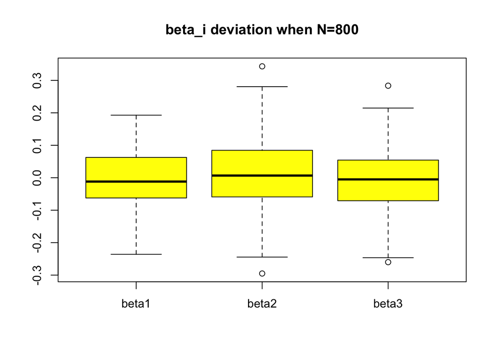

```r
tmp=data.frame(beta1=beta_hats800$beta1-beta[1],beta2=beta_hats800$beta2-beta[2],beta3=beta_hats800$beta3-beta[3])
boxplot(tmp,col = 'yellow',main='beta_i deviation when N=800')
```

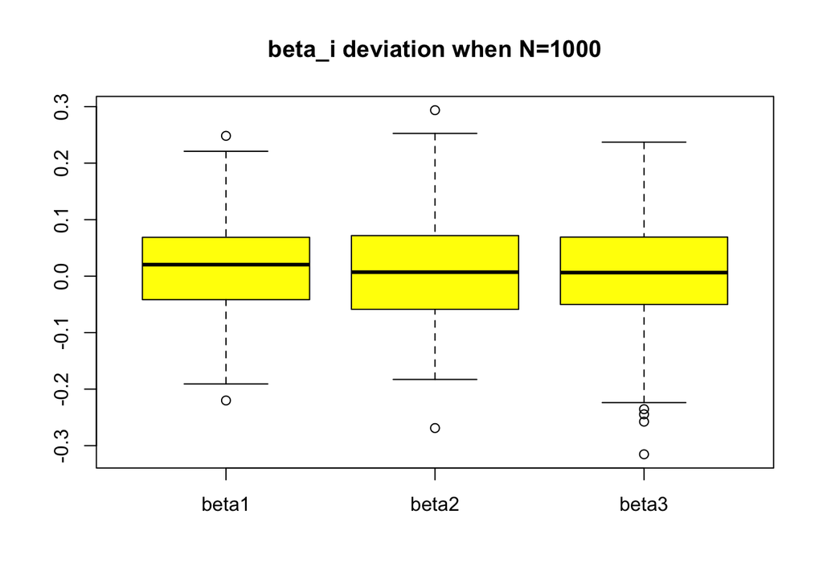

```r
tmp=data.frame(beta1=beta_hats1000$beta1-beta[1],beta2=beta_hats1000$beta2-beta[2],beta3=beta_hats1000$beta3-beta[3])
boxplot(tmp,col = 'yellow',main='beta_i deviation when N=1000')
```

### 参考：http://www.cnblogs.com/sprint1989/p/3967945.html

从本质上去看，牛顿法是二阶收敛，梯度下降是一阶收敛，所以牛顿法就更快。 从几何上说，牛顿法就是用一个二次曲面去拟合你当前所处位置的局部曲面，而梯度下降法是用一个平面去拟合当前的局部曲面，通常情况下，二次曲面的拟合会比平面更好，所以牛顿法选择的下降路径会更符合真实的最优下降路径。